# Flights Data Analysis

## by Ahmed Mokhtar

## Investigation Overview

> The overall goals are to get better understanding of our data, search for the correlation between the variables, and get the disribution of the delay variable, search for the unusual correlation and get some question to answer it.

## Dataset Overview

> The data consists of 63290 records about flights in US. This records include date(month,year), Carrier name, Airport, arrival delay time, and the delay_reasons, and other various features such the number of flights, Cancelled flights, and the cancellation_reasons. The dataset (airline_delay_causes.csv) can be downloaded from ASA Section on Statistical Computing & ASA Section on Statistical Graphics.

## Number of carrier flights per month

> This plot the distibution of carrier flights per month, and it seems to be right skewed and most of the data lays below the 500

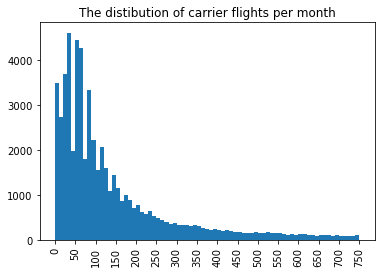

## Delay time per carrier and month

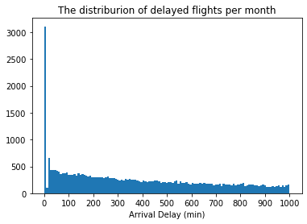

## Total flights per year

> As we can see after June 2020 the flight stops because coronavirus, and we can see the number of flights is decreasing from April

> We can see that February has the lowest flights number

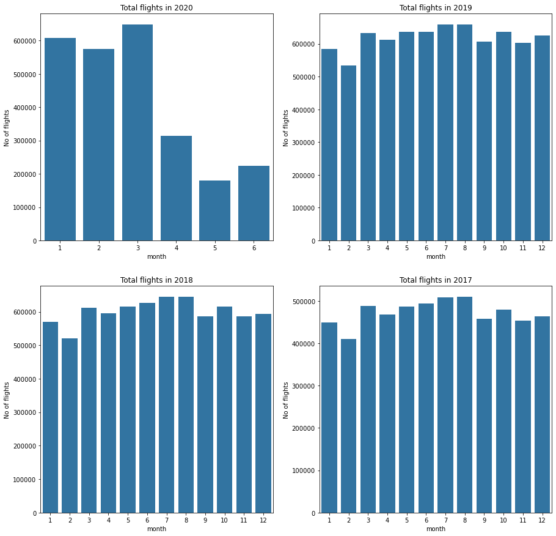

## Carrier Vs Carrier Delay

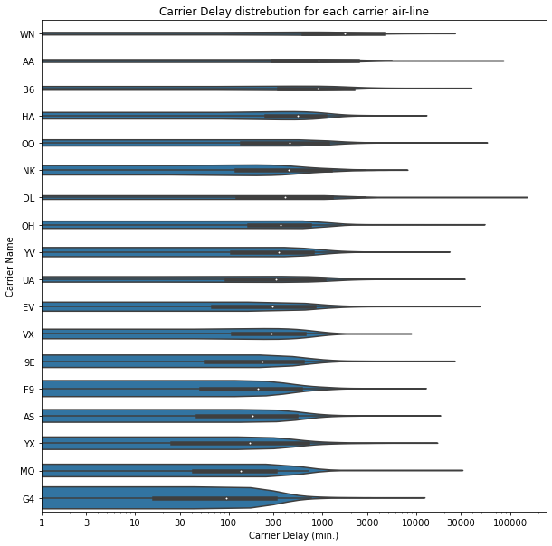

## The highest 15 number of taking-off flights from each city

> As we see CA is the most city has arrived flights, then TX, and in the last place was TT, I took the first 15 place to make a small plot because there are 53 city.

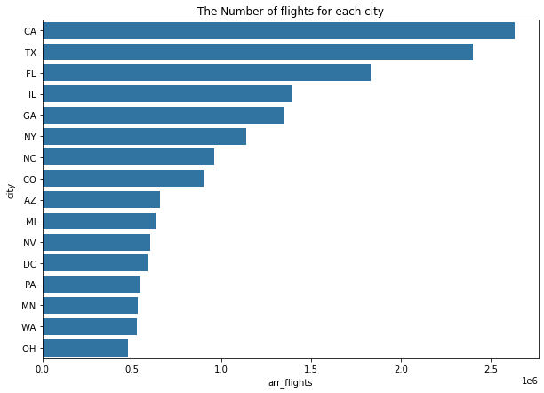

## Heatmap between (year,month and security)

> At (Nov-2017, Dec-2017, and Jun-2019) there were many flights that cancelled or delayed because security reasons, I think there were some terrorist operations or something like that in this months.

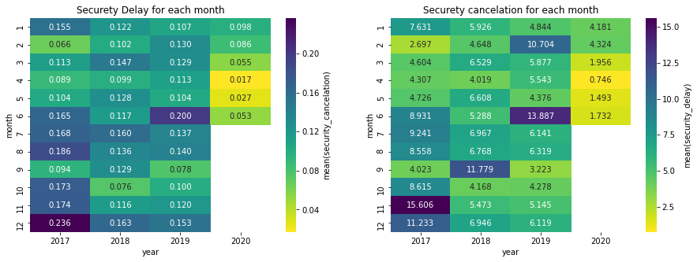